# IODS course project

### 5. Logistic regression

Logistic regression of my variables as predictors and the binary high/low alcohol consumption variable as the target is fit below, model specified as “binomial”.

```r
model0 <- glm(high_use ~ sex + studytime + goout + activities, data = alc, family = "binomial")
summary(model0) #summary of the model
```

```
##
## Call:
## glm(formula = high_use ~ sex + studytime + goout + activities,
##     family = "binomial", data = alc)
##
## Deviance Residuals:
##     Min       1Q   Median       3Q      Max
## -1.8429  -0.8130  -0.4931   0.7782   2.7235
##
## Coefficients:
##               Estimate Std. Error z value Pr(>|z|)
## (Intercept)    -2.6598     0.5751  -4.625 3.75e-06 ***
## sexM            0.7954     0.2682   2.966  0.00302 **
## studytime      -0.4564     0.1706  -2.676  0.00745 **
## goout           0.7633     0.1208   6.319 2.63e-10 ***
## activitiesyes  -0.4182     0.2599  -1.609  0.10770
## ---
## Signif. codes:  0 '***' 0.001 '**' 0.01 '*' 0.05 '.' 0.1 ' ' 1
##
## (Dispersion parameter for binomial family taken to be 1)
##
##     Null deviance: 452.04  on 369  degrees of freedom
## Residual deviance: 377.16  on 365  degrees of freedom
## AIC: 387.16
##
## Number of Fisher Scoring iterations: 4
```

```r
OR <- coef(model0) %>% exp # Coefficients as odds ratios
CI <- confint(model0) %>% exp # Confidence intervals as odds ratios
cbind(OR, CI) # odds ratios with confidence intervals
```

```
##                       OR      2.5 %    97.5 %
## (Intercept)   0.06996056 0.02196779 0.2106183
## sexM          2.21537261 1.31454903 3.7705957
## studytime     0.63353959 0.44864628 0.8776600
## goout         2.14545100 1.70430488 2.7396211
## activitiesyes 0.65825821 0.39357305 1.0928587
```

Of the selected predictors sex, studytime and going out with friends seem to associate significantly with high use of alcohol - the confidence intervals of these variables do not include 1.

Men have two times higher odds of being a high user of alcohol compared to women. Those who study more use less alcohol according to the results: for each point increase in studytime per week the students have 0.64 times lower odds of being a high consumer. Those who go out have higher odds of being high consumers, with a 2.1 times higher odds for each increase in going out score.

### 6. Predictive power

Fit a new model with the significant predictors only:

```r
model1 <- glm(high_use ~ sex + studytime +  goout, data = alc, family = "binomial")
```

```r
probabilities <- predict(model1, type = "response") # predicting probability of high_use
alc <- mutate(alc, probability = probabilities)
alc <- mutate(alc, prediction = probability > 0.5)

select(alc, high_use, sex, studytime, probability, prediction) %>% tail(10)
```

```
## # A tibble: 10 × 5
##    high_use sex   studytime probability prediction
##    <lgl>    <chr>     <dbl>       <dbl> <lgl>
##  1 FALSE    M             2      0.325  FALSE
##  2 FALSE    M             1      0.272  FALSE
##  3 TRUE     M             1      0.441  FALSE
##  4 FALSE    F             3      0.125  FALSE
##  5 FALSE    F             1      0.277  FALSE
##  6 FALSE    F             3      0.0631 FALSE
##  7 FALSE    F             2      0.331  FALSE
##  8 FALSE    F             2      0.0497 FALSE
##  9 TRUE     M             1      0.779  TRUE
## 10 TRUE     M             1      0.150  FALSE
```

Cross tabulation of predictions versus the actual values:

```r
table(high_use = alc$high_use, prediction = alc$prediction)
```

```
##         prediction
## high_use FALSE TRUE
##    FALSE   234   25
##    TRUE     58   53
```

Calculate proportion of inaccurately classified students. I use the function from the exercise set:

```r
loss_func <- function(class, prob) {
  n_wrong <- abs(class - prob) > 0.5
  mean(n_wrong)
}
loss_func(class = alc$high_use, prob = alc$probability)
```

```
## [1] 0.2243243
```

Around 22% of the predictions were wrong. Same as (figures from the crosstabulation):

```r
(25+58)/370
```

```
## [1] 0.2243243
```

Finally, a graphic visualization of both the actual values and the predictions:

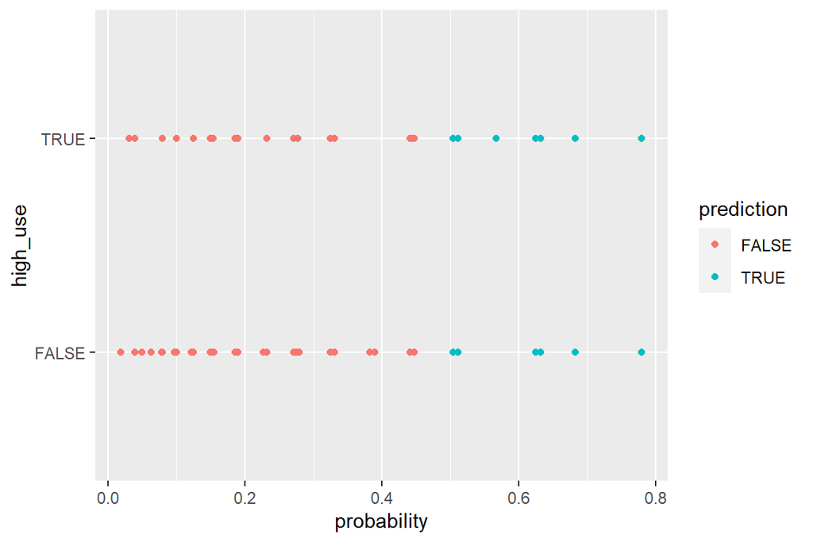

```r
ggplot(alc, aes(x = probability, y = high_use, col = prediction)) +
  geom_point()
```

# Week 4. Clustering and classification

```r
date()
```

```
## [1] "Sun Dec 11 13:14:47 2022"
```

```r
# Packages
library(MASS); library(corrplot); library(ggplot2); library(GGally); library(tidyr)
```

### 2. Load data and explore

```r
# Load data

data("Boston")
```

This weeks exercise uses the Boston dataset from the MASS package. The dataset contains information related to values of housing in different suburbs of Boston. It includes variables such as per capita crime rate (the main focus here in the exercise), average number of rooms per dwelling and distances to employment centres, for example. More info available at: https://stat.ethz.ch/R-manual/R-devel/library/MASS/html/Boston.html.

```r
# Explore dataset
str(Boston)
```

```
## 'data.frame':    506 obs. of  14 variables:
##  $ crim   : num  0.00632 0.02731 0.02729 0.03237 0.06905 ...
##  $ zn     : num  18 0 0 0 0 0 12.5 12.5 12.5 12.5 ...
##  $ indus  : num  2.31 7.07 7.07 2.18 2.18 2.18 7.87 7.87 7.87 7.87 ...
##  $ chas   : int  0 0 0 0 0 0 0 0 0 0 ...
##  $ nox    : num  0.538 0.469 0.469 0.458 0.458 0.458 0.524 0.524 0.524 0.524 ...
##  $ rm     : num  6.58 6.42 7.18 7 7.15 ...
##  $ age    : num  65.2 78.9 61.1 45.8 54.2 58.7 66.6 96.1 100 85.9 ...
##  $ dis    : num  4.09 4.97 4.97 6.06 6.06 ...
##  $ rad    : int  1 2 2 3 3 3 5 5 5 5 ...
##  $ tax    : num  296 242 242 222 222 222 311 311 311 311 ...
##  $ ptratio: num  15.3 17.8 17.8 18.7 18.7 18.7 15.2 15.2 15.2 15.2 ...
##  $ black  : num  397 397 393 395 397 ...
##  $ lstat  : num  4.98 9.14 4.03 2.94 5.33 ...
##  $ medv   : num  24 21.6 34.7 33.4 36.2 28.7 22.9 27.1 16.5 18.9 ...
```

The data has 506 observations and 14 variables. Two of the variables are integer - chas: dummy variable describing if tract bounds river or not, and rad: index of accessibility to radial highways. Others variables are numerical.

```r
# Summaries of the variables
summary(Boston)
```

```
##       crim                zn             indus            chas
##  Min.   : 0.00632   Min.   :  0.00   Min.   : 0.46   Min.   :0.00000
##  1st Qu.: 0.08205   1st Qu.:  0.00   1st Qu.: 5.19   1st Qu.:0.00000
##  Median : 0.25651   Median :  0.00   Median : 9.69   Median :0.00000
##  Mean   : 3.61352   Mean   : 11.36   Mean   :11.14   Mean   :0.06917
##  3rd Qu.: 3.67708   3rd Qu.: 12.50   3rd Qu.:18.10   3rd Qu.:0.00000
##  Max.   :88.97620   Max.   :100.00   Max.   :27.74   Max.   :1.00000
##       nox               rm             age              dis
##  Min.   :0.3850   Min.   :3.561   Min.   :  2.90   Min.   : 1.130
##  1st Qu.:0.4490   1st Qu.:5.886   1st Qu.: 45.02   1st Qu.: 2.100
##  Median :0.5380   Median :6.208   Median : 77.50   Median : 3.207
##  Mean   :0.5547   Mean   :6.285   Mean   : 68.57   Mean   : 3.795
##  3rd Qu.:0.6240   3rd Qu.:6.623   3rd Qu.: 94.08   3rd Qu.: 5.188
##  Max.   :0.8710   Max.   :8.780   Max.   :100.00   Max.   :12.127
##       rad              tax           ptratio          black
##  Min.   : 1.000   Min.   :187.0   Min.   :12.60   Min.   :  0.32
##  1st Qu.: 4.000   1st Qu.:279.0   1st Qu.:17.40   1st Qu.:375.38
##  Median : 5.000   Median :330.0   Median :19.05   Median :391.44
##  Mean   : 9.549   Mean   :408.2   Mean   :18.46   Mean   :356.67
##  3rd Qu.:24.000   3rd Qu.:666.0   3rd Qu.:20.20   3rd Qu.:396.23
##  Max.   :24.000   Max.   :711.0   Max.   :22.00   Max.   :396.90
##      lstat            medv
##  Min.   : 1.73   Min.   : 5.00
##  1st Qu.: 6.95   1st Qu.:17.02
##  Median :11.36   Median :21.20
##  Mean   :12.65   Mean   :22.53
##  3rd Qu.:16.95   3rd Qu.:25.00
##  Max.   :37.97   Max.   :50.00
```